# Figure 4

Jaime So

2025-08-14

# Figure 4: B-type VSGs are evenly represented across subspecies genomes.

## A

The proportion of enriched peptides in gHAT patient serum that are from type B NTDs is much higher than expected.

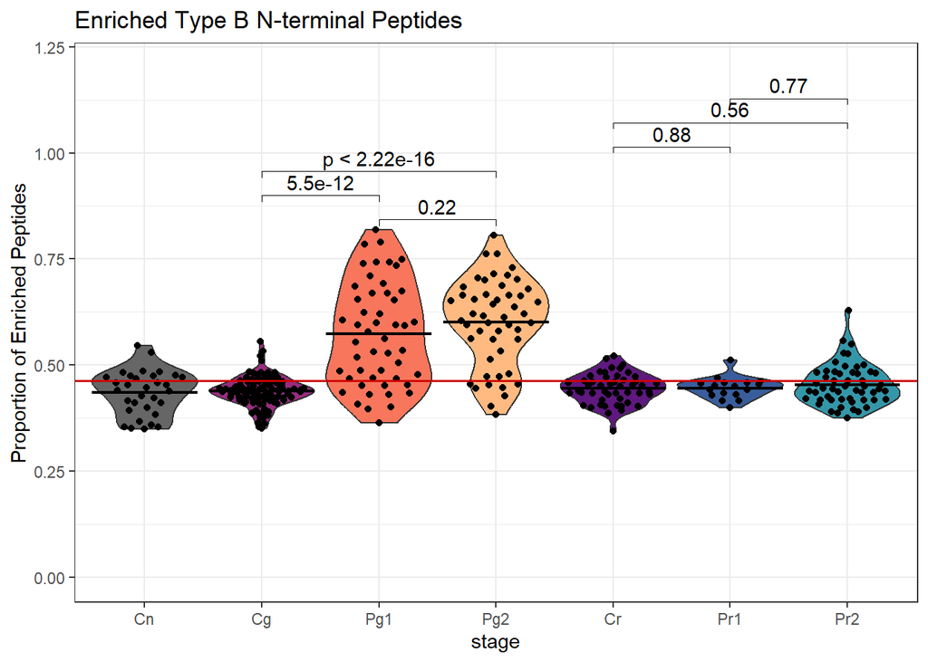

```r
# find the expected proportions of NTD types based on the represented library phages
lib_peps <- read_csv("FigureData/fc_mat.csv", show_col_types = FALSE) %>% .$Peptide
lib_expect <- read_csv("FigureData/VSG_Tile_Classification.csv", show_col_types = FALSE) %>% filter(pep_id %in% lib_peps) %>% filter(pep_region == "N-terminal") %>%
  group_by(nterm_typesubtype) %>% summarise(n = n())
lib_expect <- lib_expect %>% mutate(prop = n/(read_csv("FigureData/VSG_Tile_Classification.csv", show_col_types = FALSE) %>% filter(pep_id %in% lib_peps) %>% filter(pep_region == "N-terminal") %>% nrow()))

# make a df containing significantly enriched peptides and their annotations
Nterms <- read_csv("FigureData/sig_peps.csv") %>% select(Peptide, sample) %>% distinct() %>%
  mutate(stage = case_when(grepl("Pg1", .$sample)~"Pg1",
                           grepl("Pg2", .$sample)~"Pg2",
                           grepl("Pr1", .$sample)~"Pr1",
                           grepl("Pr2", .$sample)~"Pr2",
                           grepl("Cg", .$sample)~"Cg",
                           grepl("Cr", .$sample)~ "Cr",
                           grepl("NC", .$sample)~"Cn"))
Nterms <- inner_join(Nterms, read_csv("FigureData/VSG_Tile_Classification.csv", show_col_types = FALSE), by = c("Peptide"="pep_id"))
plot_nterm <- Nterms %>% filter(pep_region == "N-terminal") %>% select(Peptide, sample, nterm_typesubtype) %>% group_by(sample, nterm_typesubtype) %>%
  summarise(n = n()) %>% group_by(sample) %>% mutate(total = sum(n))
plot_nterm <- inner_join(plot_nterm, Nterms %>% select(sample, stage) %>% distinct()) %>% mutate(prop = n/total)
plot_nterm$stage <- factor(plot_nterm$stage, levels = c("Cn", "Cg", "Pg1", "Pg2", "Cr", "Pr1", "Pr2"))

B_means <- plot_nterm %>% filter(nterm_typesubtype == "B1") %>% group_by(stage) %>% summarise(prop = mean(prop))

# plot proportions of enriched type B NTD peptides per sample
plot_nterm %>% filter(nterm_typesubtype == "B1") %>%
  ggplot(aes(x = stage, y = prop, fill = stage))+
  geom_violin(scale = "width")+
  geom_quasirandom()+
  geom_hline(data = lib_expect %>% filter(nterm_typesubtype == "B1"), aes(yintercept = prop), color = "red3", linewidth = 0.6)+
  geom_crossbar(data = B_means, aes(min = prop, ymax = prop), linewidth = 0.3)+
  scale_fill_manual(values = c("grey40", "#982D80FF", "#F8765CFF", "#FEBA80FF", "#5F187FFF", "#395D9CFF", "#3497A9FF"))+
  scale_y_continuous(limits = c(0, 1.2), "Proportion of Enriched Peptides")+
  stat_compare_means(comparisons = list(c("Pg1", "Pg2"), c("Cg", "Pg1"), c("Cg", "Pg2"), c("Cr", "Pr1"), c("Cr", "Pr2"), c("Pr1", "Pr2")))+
  theme(text = element_text(size = 20))+
  ggtitle("Enriched Type B N-terminal Peptides")+
  theme_bw() + theme(legend.position = "none")
```

## B

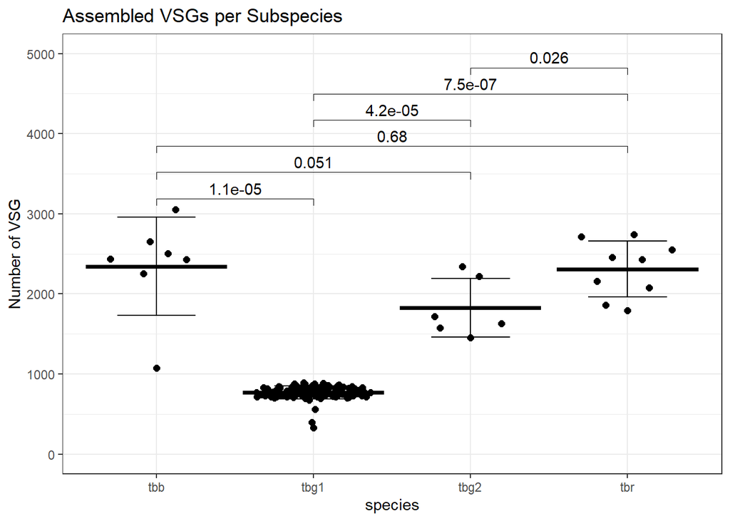

```r
Assembled_VSG <- read_csv("FigureData/complete_assembly_data.csv", show_col_types = FALSE)
# extended metadata for each strain used in the VSG assembly
all_meta <- Assembled_VSG %>% select(strain_name, SRA_accession, year, country, species) %>% distinct()

count_VSG <- Assembled_VSG %>% count(species, strain_name)

stats_count <- count_VSG %>% group_by(species) %>%
  summarise(avg = mean(n), sd = sd(n)) %>%
  plyr::rename(c("avg"="n"))

count_VSG %>%
ggplot(aes(x = species, y = n))+
  geom_quasirandom(size = 2) +
  geom_crossbar(data = stats_count, aes(ymin = n, ymax = n), linewidth = 0.5) +
  geom_errorbar(data = stats_count, aes(ymin = (n - sd), ymax = (n + sd)), width = 0.5) +
  scale_y_continuous(limits = c(0,5000)) +
  ylab("Number of VSG") +
  stat_compare_means(comparisons = list( c("tbb", "tbg1"), c("tbb", "tbg2"), c("tbb", "tbr"), c("tbg1", "tbg2"), c("tbg1", "tbr"), c("tbg2", "tbr"))) +
  theme(text = element_text(size=20), legend.position = "none", axis.text.x = element_text(angle = 45, vjust = 1, hjust=1)) +
  ggtitle("Assembled VSGs per Subspecies") +
  theme_bw()
```

## C

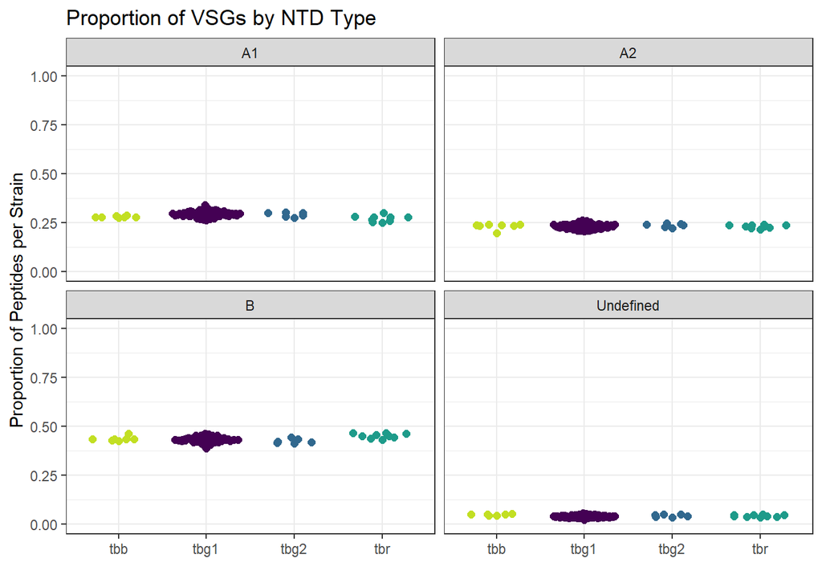

```r
# simplify by grouping all A1 (A1a, A1b, A1c) subtypes together
class_comp <- Assembled_VSG %>%
  mutate(class = case_when((nterm_typesubtype == "1a" | nterm_typesubtype == "1b" | nterm_typesubtype == "1c" ~ "A1"),
                           nterm_typesubtype == "B1" ~ "B",
                           TRUE ~ nterm_typesubtype)) %>%
  count(species, strain_name, class) %>%
  group_by(strain_name) %>% mutate(total = sum(n)) %>%
  mutate(prop = n/total)

class_comp$class <- replace_na(class_comp$class, "Undefined")



p <- class_comp %>% group_by(species, strain_name, class) %>% summarise(plotprop = sum(prop)) %>%
  ggplot(aes(x = species , y = plotprop, color = species)) +
  scale_color_manual(values = c("#C2DF23FF", "#440154FF", "#31688EFF", "#1E9B8AFF")) +
  geom_quasirandom(size = 2) +
  scale_y_continuous(limits = c(0,1)) +
  labs(title = "Proportion of VSGs by NTD Type",
       x = "",
       y = "Proportion of Peptides per Strain") +
  facet_wrap(~class) +
  theme_bw()
p + theme(legend.position = "none")
```

```r
# the genomic class composition is not different between the T.b. subspecies
```

# Assembling VSG repertoires of field isolates

Altered the original VSG-seq pipeline to only perform the assembly and cd-hit collapse steps and none of the expression quantification.

Due to the unique biology of trypanosomes, namely the polycistronic transcription and complete lack of introns, we can assemble ORFs no problem from genomic illumina short reads using Trinity even though it is designed for Transcriptome assemblies.

## Sequences scraped from Data Dryad and ENA

Many of the datasets we found were featured in whole genome phylogenetic studies. Richardson et.al. 2015 (doi:10.1111/eva.12338) explores whether disease relapse of Tbg after treatment of patients in DRC was due to reinfection or recrudescence. The BT before treatment and AT/REL strains were highly similar suggesting it was indeed recrudescence in all cases.

Weir et.al 2015 (DOI: 10.7554/eLife.11473) performed a phylogenetic network analysis on a large number of Tb strains: 75 Tbg1, 4 Tbg2, 4 Tbr, and 2 Tbb. Their analysis showed a distinct lack of heterozygosity which is indicative of clonal expansion of the Tbg1 strains. The major Tbg endemic countries represented had distinct lineages circulating within.

## Trinity ORF Assembly

Assembly using Trinity and ORF done using the VSG-seq methodology, calling with a VSG length cutoff of 300AA.

VSG-seq input command:

```r
% python VSG_identify.py -i VSGid_input.txt -header All_Assemblies -cpu 24 -mem 100 -vsgdb concatAnTattb427 -v 0 -sit 1 -t 0
```

halt the VSG-seq pipeline after initial trinity assembly and VSG ORF-calling using blast. Concatenate all assembled VSG sequences with Jaclyn’s fasta of all characterized tbb VSGs, then perform cd-hit clustering.

Clustering with cd-hit at a nucleotide sequence identity of 100% to only exclude true duplicates, later we can cluster by lower thresholds to try and establish families or otherwise determine repertoire similarity thresholds.

# Mapping Library Tiles to Assembled VSG

Compare tiles to assembled VSG using a similar approach to what we did for the breadth analysis. We get much better resolution by tiling the peptides first so we can see regions of high similarity within the sequence rather than blast’s more global summary across the full alignment.

Use this data to answer questions: - which VSGs are fully represented? - what is the proportion of VSGs that are missing from each subspecies of Trypanosoma? - when portions of the VSG are unrepresented by tiles, what region of the VSG is it? CTD vs NTD? - Are certain NTD types underrepresented by the library tiles?

## Summarize coverage

```r
# consider unique sequences

type_ref <- Assembled_VSG %>% select(VSG_name, original_seq_length, nterm_seq_length, HMM_profile, nterm_typesubtype) %>% distinct()
# the dataframe type_ref contains the total length of all assembled VSGs

# summarizing the spans may be faster if we subset the data first, by nterm subtype
read_genomecov <- function(range){
  x <- type_ref[range, ] # df of protein types and lengths
  y <- blast_out %>% filter(VSG %in% unique(x$VSG_name)) # df of alignment coords
  # use iranges package for visualization
  plotR <- data.frame(start = double(),
                      end = double(),
                      width = double(),
                      seq_ID = character())
  for (i in 1:length(x$original_seqID)) {
    irR <- IRanges(y[y$VSG == x$VSG_name[i], ] %>%
                   select(VSG, start, end) %>%
                   distinct() %>%
                   .$start,
                 end = y[y$VSG == x$VSG_name[i], ] %>%
                   select(VSG, start, end) %>%
                   distinct() %>%
                   .$end)
    # collapse overlapping regions to calculate seq_ID coverage
    cov <- IRanges::reduce(irR) %>% as.data.frame()
    cov <- cov %>% mutate(VSG_name = x$VSG_name[i])
    plotR <- rbind(plotR, cov)
    }
  plotR <- merge(plotR, x)
  return(plotR)
}


unique(type_ref$VSG_name) %>% length()
nrow(type_ref)
# sequentially summarize all aligned spans for the 77k assembled VSG and add them to a dataframe

temp <- read_genomecov(1:5000)
mapped_tiles <- rbind(temp, read_genomecov(5001:10000))
mapped_tiles <- rbind(mapped_tiles, read_genomecov(10001:15000))
mapped_tiles <- rbind(mapped_tiles, read_genomecov(15001:20000))
mapped_tiles <- rbind(mapped_tiles, read_genomecov(20001:25000))
mapped_tiles <- rbind(mapped_tiles, read_genomecov(25001:30000))
mapped_tiles <- rbind(mapped_tiles, read_genomecov(30001:35000))
mapped_tiles <- rbind(mapped_tiles, read_genomecov(35001:40000))
mapped_tiles <- rbind(mapped_tiles, read_genomecov(40001:45000))
mapped_tiles <- rbind(mapped_tiles, read_genomecov(45001:50000))
mapped_tiles <- rbind(mapped_tiles, read_genomecov(50001:55000))
mapped_tiles <- rbind(mapped_tiles, read_genomecov(55001:60000))
mapped_tiles <- rbind(mapped_tiles, read_genomecov(60001:65000))
mapped_tiles <- rbind(mapped_tiles, read_genomecov(65001:70000))
mapped_tiles <- rbind(mapped_tiles, read_genomecov(70001:75000))
mapped_tiles <- rbind(mapped_tiles, read_genomecov(75001:nrow(type_ref)))

# save results as a csv for loading later
#write_csv(mapped_tiles, file = "TileLibCoverage_results.csv")
```

# Supplemental Figure S1

## S1B

Quantify which parts of the VSG protein (i.e. domain) are missing from the library

```r
type_ref <- Assembled_VSG %>% select(VSG_name, original_seq_length, nterm_seq_length, HMM_profile, nterm_typesubtype) %>% distinct()
mapped_tiles <- read_csv("FigureData/TileLibCoverage_results.csv", show_col_types = FALSE)

# we must also include entries for any VSGs that had 0 hits
no_mapping <- data.frame(VSG_name = setdiff(type_ref$VSG_name, unique(mapped_tiles$VSG_name))) %>%
  inner_join(type_ref %>% select(VSG_name, original_seq_length)) %>%
  mutate(align = 0, cov = 0) %>%
  select(VSG_name, align, original_seq_length, cov)
# calculate proportion of coverage per VSG
VSG_cov <- mapped_tiles %>%
  group_by(VSG_name) %>% summarise(align = sum(width)) %>%
  merge(mapped_tiles %>% select(VSG_name, original_seq_length) %>% distinct()) %>%
  mutate(cov = align/original_seq_length) %>%
  rbind(no_mapping) %>%
  inner_join(Assembled_VSG) %>%
  select(VSG_name, cov, nterm_typesubtype, strain_name, species)
# where does the Nterm coord usually fall
binVSG <- mapped_tiles %>% dplyr::select(VSG_name, nterm_seq_length, original_seq_length) %>% distinct() %>% mutate(Nterm = nterm_seq_length / original_seq_length)
print(summary(binVSG$Nterm))
```

```
##    Min. 1st Qu.  Median    Mean 3rd Qu.    Max.    NA's
##  0.1452  0.8235  0.8747  0.8697  0.9422  1.0000    2026
```

```r
# notice the quartiles in the summary, the vast majority of NTDs occupy ~80-90% of the VSG coding sequence

# filter the df for VSG that follow this pattern, exclude VSGs with no types

binVSG <- binVSG %>% filter(Nterm > 0.65 & Nterm < 0.95)

# merge with the mapped tiles dataframe
DomainCov <- inner_join(mapped_tiles, binVSG)
spans <- data.frame(VSG = character(),
                    CTDlen = double(),
                    Nterm = double(),
                    Cterm = double())

# the NTDs have the start coordinate at 1 instead of 0 so ad +1 to the difference for calculating coverage
for (i in 1:nrow(DomainCov)){
  x <- DomainCov[i, ]
  y <-data.frame( VSG = x$VSG_name,
                  CTDlen = (x$original_seq_length - x$nterm_seq_length),
                  Nterm = case_when(x$start >= x$nterm_seq_length ~ 0, # start after
                                 (x$start <= x$nterm_seq_length & x$end >= x$nterm_seq_length) ~ (x$nterm_seq_length - x$start + 1), # start in end out
                                 (x$start <= x$nterm_seq_length & x$end <= x$nterm_seq_length) ~ (x$end - x$start) #within
                                 ),
                  Cterm = case_when(x$end <= x$nterm_seq_length ~ 0, # end before
                                 (x$start <= x$nterm_seq_length & x$end >= x$nterm_seq_length) ~ (x$end - x$nterm_seq_length), # start out end in
                                 (x$start >= x$nterm_seq_length & x$end <= x$original_seq_length) ~ (x$end - x$start) #within
                                 )
                  )
  spans <- rbind(spans,y)
}

spans <- spans %>% group_by(VSG, CTDlen) %>% summarise(Nterm = sum(Nterm), Cterm = sum(Cterm)) %>%
  inner_join(mapped_tiles %>% select(VSG_name, nterm_seq_length, original_seq_length) %>% distinct(), by = c("VSG"="VSG_name"))
```

[output not shown]

```r
# calculate NTD coverage
N_cov <- spans %>%
  mutate(cov = Nterm/nterm_seq_length) %>%
  inner_join(Assembled_VSG, by=c("VSG"="VSG_name")) %>%
  select(VSG, cov, nterm_typesubtype, strain_name, species)
colnames(N_cov)[1] <- c("VSG_name")

C_cov <- spans %>%
  mutate(cov = Cterm/CTDlen) %>%
  inner_join(Assembled_VSG, by=c("VSG"="VSG_name")) %>%
  select(VSG, cov, nterm_typesubtype, strain_name, species)
colnames(C_cov)[1] <- c("VSG_name")

pctcov <- rbind(VSG_cov %>% mutate(type = "full ORF"),
                N_cov %>% mutate(type = "NTD"),
                C_cov %>% mutate(type = "CTD"))

# how many VSG per strain are very well represented vs those that are less well represented
# anything with < 80% coverage is poorly represented
species_binned <- pctcov %>%
  group_by(strain_name) %>%
  mutate(bins = case_when(cov >= 0.8 & type == "full ORF" ~ "Full ORF",
                          cov >= 0.8 & type == "NTD" ~ "N-Terminal Domain",
                          cov >= 0.8 & type == "CTD" ~ "C-Terminal Domain",
                          TRUE ~ "poor")) %>%
  group_by(species, strain_name, type, bins) %>%
  summarise(n = n())
```

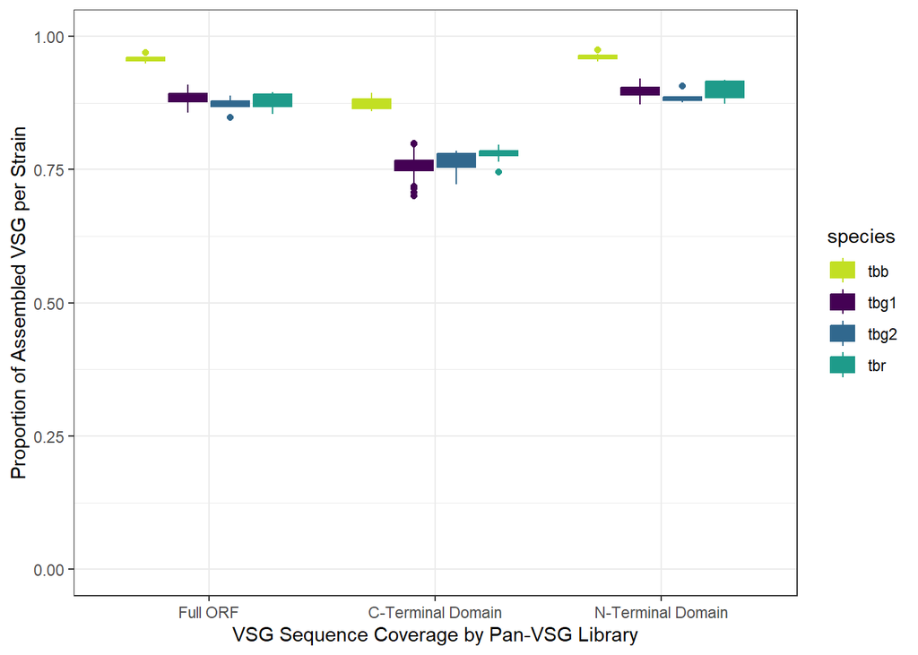

```r
# find the total number of VSG for each strain
species_binned <- species_binned %>% group_by(strain_name, type) %>% mutate(total = sum(n), prop = n/total)

species_binned$bins <- factor(species_binned$bins, levels = c("Full ORF", "C-Terminal Domain", "N-Terminal Domain", "poor"))

# boxplots
ggplot(species_binned %>% filter(!(bins == "poor")), aes(x = bins, y = prop, fill = species, color = species)) +
  geom_boxplot() +
  scale_color_manual(values = c("#c2df23ff", "#440154ff", "#31688eff", "#1e9b8aff")) +
  scale_fill_manual(values = c("#c2df23ff", "#440154ff", "#31688eff", "#1e9b8aff")) +
  scale_y_continuous(limits = c(0,1)) +
  ylab("Proportion of Assembled VSG per Strain") +
  xlab("VSG Sequence Coverage by Pan-VSG Library") +
  theme_bw()
```

# Assembly QC

How well do the assembled VSGs recapitulate known repertoires. Compare VSGs from the three Lister427 clones we assembled to the complete annotated VSGenome from https://tryps.rockefeller.edu/sequences.html

vsgs_tb427_all_atleast150aas_cds.fasta was the file used as reference for Lister 427. it contains 4211 sequences. We may want to filter it for longer VSGs like we did for our assembled output.

```r
# make blastdb
% makeblastdb -in <inputfile.fasta> -out <outputfile> -parse_seqids -dbtype nucl

# do blastdn
% blastn -db <blast_database> -query <inputfile.fasta> -out <outputfile.csv> -outfmt "10 qseqid sseqid qlen slen length nident"
```

## References

```r
# the reference contains VSG fragments down to 150aa
# we filtered our VSG-seq output for sequences of at least 300aa
# how many reference VSG are this size?

# the reference is full of "designated duplicate" VSGs, don't count these
fastafile <- readDNAStringSet("FigureData/vsgs_tb427_all_atleast150aas_cds.fasta.txt")
Lister427ref <- data.frame(name = names(fastafile), seq =paste(fastafile)) %>% mutate(seq_length = nchar(seq)) %>% filter(!grepl("Duplicate", name))

print(paste("Number of Unique Lister 427 VSGs:", nrow(Lister427ref)))
```

```
## [1] "Number of Unique Lister 427 VSGs: 4168"
```

```r
# simplify the VSG ids so we can match them to the blast data
Lister427ref$sseqid <- str_split_fixed(Lister427ref$name, " : ", n=5)[, 1]
Lister427ref$sseqid <- str_split_fixed(Lister427ref$sseqid, " GB", n=2)[, 1]

Lister300aa <- Lister427ref %>% filter(seq_length >= 900) %>% .$sseqid

# blast of assembled VSG to Lister 427 CDS from George Cross' database
assembly_check <- read_csv("FigureData/assembly_check.csv", show_col_types = FALSE, col_names = F)
colnames(assembly_check) <- c("qseqid", "sseqid", "qlen", "slen", "length", "nident")
```

## Lister 427 assemblies

- Lister427_2T1 Accession: ERR7929303 & ERR7929302
- Lister427_2060 Accession: ERR7929309 & ERR7929308
- Lister 427 BSF Accession: SRR24321266

```r
Lister427 <- Assembled_VSG %>% filter(strain_name == "Lister427_2T1" | strain_name == "Lister427BSF" | strain_name == "Lister427_2060") %>% select(VSG_name, original_seqID, strain_name, SRA_accession) %>%
  inner_join(assembly_check, by = c("original_seqID"="qseqid"))
# calculate % query aligned and % identity across the whole length of the VSG
Lister427 <- Lister427 %>% mutate(percent_identity = (nident/qlen)*100, percent_query_aligned = (length/qlen)*100)

# Filter for the best hits on each of the reference VSGs
Lister427_best <- Lister427 %>% group_by(strain_name, VSG_name) %>% summarise(best_hit = max(percent_identity), best_align = max(percent_query_aligned))
# how many VSGs aligned per strain?
inner_join(Lister427_best %>% group_by(strain_name) %>% summarise(n_aligned=n()),
           Assembled_VSG %>% filter(species == "tbb") %>% group_by(strain_name) %>% summarise(total = n()))
```

```
## # A tibble: 3 × 3
##   strain_name    n_aligned total
##   <chr>              <int> <int>
## 1 Lister427BSF        2250  2251
## 2 Lister427_2060      2505  2507
## 3 Lister427_2T1       2433  2435
```

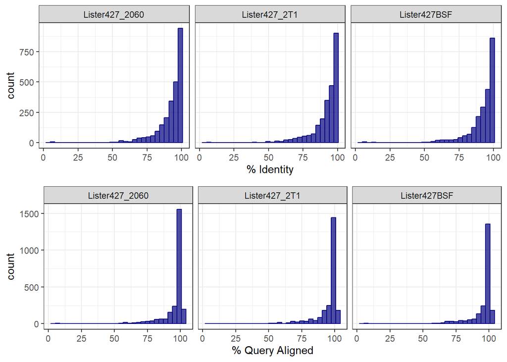

```r
# nearly all of the assembled VSG have a hit in the Lister reference

plot_grid(
Lister427_best %>%
  ggplot(aes(x = best_hit)) +
  geom_histogram(color = "navy", fill = "navy", alpha = 0.7) +
  theme_bw() +
  facet_wrap(~strain_name)+
  xlab("% Identity"),
Lister427_best %>%
  ggplot(aes(x = best_align)) +
  geom_histogram(color = "navy", fill = "navy", alpha = 0.7) +
  theme_bw() +
  facet_wrap(~strain_name)+
  xlab("% Query Aligned"),
nrow = 2
)
```

## Final S1C

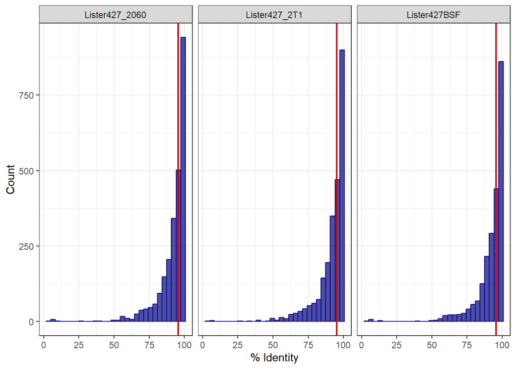

```r
plot_medians <- Lister427_best %>% group_by(strain_name) %>% summarise(best_hit = median(best_hit))

Lister427_best %>%
  ggplot(aes(x = best_hit)) +
  geom_histogram(color = "navy", fill = "navy", alpha = 0.7) +
  geom_vline(data = plot_medians, aes(xintercept = best_hit), color = "red3", linewidth = 0.8)+
  theme_bw() +
  facet_wrap(~strain_name)+
  ylab("Count")+
  xlab("% Identity")
```

```r
plot_medians
```

```
## # A tibble: 3 × 2
##   strain_name    best_hit
##   <chr>             <dbl>
## 1 Lister427BSF       95.6
## 2 Lister427_2060     95.5
## 3 Lister427_2T1      95.2
```

# Supplemental Figure 2

## S2A

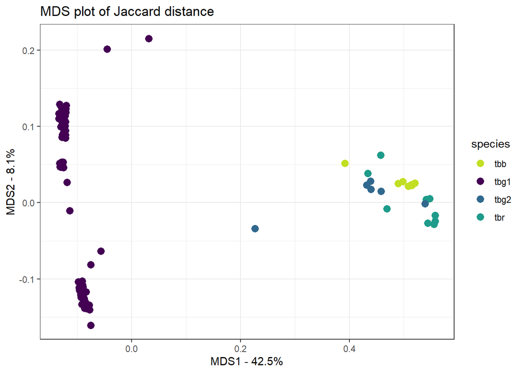

```r
# used cd-hit-est to cluster all of the assembled VSG sequences with a global identity of 80%
cluster80 <- read_table("FigureData/cdhitest80_families.txt", col_names = F, show_col_types = FALSE) %>% mutate(clustername = paste(X2, X3, sep = "_")) %>% select(X1, clustername)
colnames(cluster80)[1] <- "VSG_name"


families <- inner_join(Assembled_VSG, cluster80, by = "VSG_name")

families <- reshape2::dcast((families %>% group_by(clustername, strain_name) %>% summarise(count = n())), clustername ~ strain_name, value.var = "count")
families[is.na(families)] <- 0
clusternames <- families$clustername
families <- families %>% select(-clustername)
row.names(families) <- clusternames

fam_mat <- vegan::vegdist(t(families), binary = T, method = "jaccard") %>% as.matrix() %>% as.data.frame()

## PCoA of the distance matrix
fam =  cmdscale(fam_mat, eig=TRUE, x.ret=TRUE)
fam.var.per <- round(fam$eig/sum(fam$eig)*100, 1)
fam.values <- fam$points
fam.data <- data.frame(sample=rownames(fam.values),
  X=fam.values[,1],
  Y=fam.values[,2])

ggplot(data=fam.data %>%
         left_join(all_meta, by = c("sample"="strain_name")),
       aes(x=X, y=Y, text = sample,
           #label=sample,
           color = species))+
  #geom_text(nudge_x = 0.01, nudge_y = 0.01) +
  geom_point(size = 3)+
  xlab(paste("MDS1 - ", fam.var.per[1], "%", sep="")) +
  ylab(paste("MDS2 - ", fam.var.per[2], "%", sep="")) +
  ggtitle("MDS plot of Jaccard distance") +
  scale_color_manual(values = c("#C2DF23FF", "#440154FF", "#31688EFF", "#1E9B8AFF")) +
  theme_bw()
```

There is a large separation between the VSGs represented in the tbg1 genomes compared to strains from all other subspecies. tbg2, tbb, and tbr all cluster tightly together while the tbg1 strains cluster on the other side of the space in distinct groups that seem to be driven mainly by geography.

# Repertoire Comparisons

## Clustering

The percent identity limit for cd-hit-est nucleotide sequences is only 80%. Translate the assembled VSG to protein sequence and then try clustering all the way down to 40% global identity.

Adjust word size accordingly:

-n 5 for thresholds 0.7 ~ 1.0

-n 4 for thresholds 0.6 ~ 0.7

-n 3 for thresholds 0.5 ~ 0.6

-n 2 for thresholds 0.4 ~ 0.5

Example cd-hit command:

% cd-hit -i All_Assembled_VSG_renamed-translated.faa -o Assembled_VSG_cdhitest80 -c 0.8 -n 5 -M 16000 -d 0

Use python script to match clusters with sequence names to create tables and eventually matrices for plotting.

```r
import glob
import os, sys
import subprocess
from sys import argv

# Jaime: I edited this script from Jaclyn so that you can enter files named differently
# - argv[1] is the VSG-seq output .clstr file
# - argv[2] is the name of the output file
currDir = os.getcwd()

cluster_dict = {}
with open(argv[1],'r') as infile_split:
    with open(argv[2],'w+') as reference:
        for line in infile_split:
            if line.startswith('>'):
                clean_line = line.split('>')
                cluster_dict[clean_line[1]] = []
                lastline = clean_line[1]
            else:
                newline = line.split()
                if len(newline) >1:
                    final = newline[2].split('>')
                    final = final[1].split('...')
                    cluster_dict[lastline].append(final[0])

        for key, value in cluster_dict.items():
            for item in value:
                reference.write(str(item + '\t' + key))
```

## Plotting

```r
# used cd-hit- to cluster assembled VSG sequences with a range of global % identities

filelist <- c(list.files(path = "FigureData/cd-hit_VSGfam/", pattern = ".*._families.txt", full.names = T))
df <- rbindlist(sapply(filelist, fread, simplify = FALSE), use.names = FALSE, idcol = "PID")
# fix the column names, one of the data rows was made the column names
addentry <- data.frame(PID = "FigureData/cd-hit_VSGfam/cdhit40_families.txt", VSG_name = "Assembled_VSG_26798", Cluster = "Cluster 0")
colnames(df) <- c("PID", "VSG_name", "Cluster")
df <- rbind(addentry, df)

df <- df %>% mutate(PID = str_remove(PID, pattern = "_families.txt")) %>%
  mutate(PID = str_remove(PID, pattern = "FigureData/cd-hit_VSGfam/cdhit"))

# add strain and VSG annotation info
df <- merge(Assembled_VSG, df)
```

## Jaccard Distance

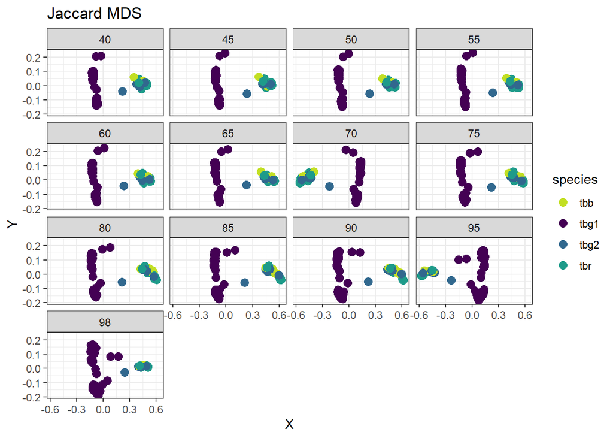

```r
jaccard.mds <- data.frame(sample = character(),
                        X=double(),
                        Y=double(),
                        PID = character())

for (i in 1:length(unique(df$PID))){
  families <- reshape2::dcast(df %>% filter(PID == unique(df$PID)[i]) %>% group_by(Cluster, strain_name) %>% summarise(count = n()), Cluster ~ strain_name, value.var = "count")
  families[is.na(families)] <- 0
  clusternames <- families$Cluster
  families <- families %>% dplyr::select(-Cluster)
  row.names(families) <- clusternames

  mds_mat <- vegan::vegdist(t(families), binary=T, method = "jaccard") %>% as.matrix() %>% as.data.frame()

# PCoA of distance matrix
  mds <- cmdscale(mds_mat, eig = TRUE, x.ret = TRUE)
  mds.var.per <- round(mds$eig/sum(mds$eig)*100, 1)
  mds.values <- mds$points
  mds.data <- data.frame(sample = rownames(mds.values),
                              X=mds.values[,1],
                              Y=mds.values[,2]) %>%
    mutate(PID = unique(df$PID)[i])
  jaccard.mds <- rbind(jaccard.mds, mds.data)
}

jaccard.mds <- jaccard.mds %>%
         left_join(all_meta, by = c("sample"="strain_name"))

ggplot(data=jaccard.mds,
       aes(x=X, y=Y, text=sample,
           #label=sample,
           color=species))+
  #geom_text(nudge_x=0.01, nudge_y=0.01)+
  geom_point(size=3)+
  facet_wrap(~PID)+
  ggtitle("Jaccard MDS")+
  scale_color_manual(values = c("#c2df23ff", "#440154ff", "#31688eff", "#1e9b8aff"))+
  theme_bw()
```

# Supplemental Figure S2B

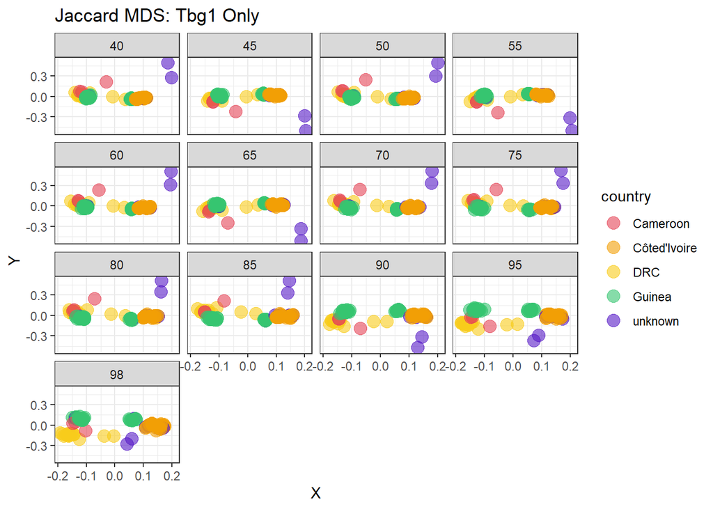

```r
tbg.jaccard.mds <- data.frame(sample = character(),
                        X=double(),
                        Y=double(),
                        PID = character())

for (i in 1:length(unique(df$PID))){
  families <- reshape2::dcast(df %>% filter(PID == unique(df$PID)[i] & species == "tbg1") %>% group_by(Cluster, strain_name) %>% summarise(count = n()), Cluster ~ strain_name, value.var = "count")
  families[is.na(families)] <- 0
  clusternames <- families$Cluster
  families <- families %>% select(-Cluster)
  row.names(families) <- clusternames

  mds_mat <- vegan::vegdist(t(families), binary=T, method = "jaccard") %>% as.matrix() %>% as.data.frame()

# PCoA of distance matrix
  mds <- cmdscale(mds_mat, eig = TRUE, x.ret = TRUE)
  mds.var.per <- round(mds$eig/sum(mds$eig)*100, 1)
  mds.values <- mds$points
  mds.data <- data.frame(sample = rownames(mds.values),
                              X=mds.values[,1],
                              Y=mds.values[,2]) %>%
    mutate(PID = unique(df$PID)[i])
  tbg.jaccard.mds <- rbind(tbg.jaccard.mds, mds.data)
}

tbg.jaccard.mds <- tbg.jaccard.mds %>%
         left_join(all_meta, by = c("sample"="strain_name"))
tbg.jaccard.mds$PID <- as.numeric(tbg.jaccard.mds$PID)

g1 <- ggplot(data=tbg.jaccard.mds,
       aes(x=X, y=Y, text=sample,
           #label=sample,
           color=country))+
  #geom_text(nudge_x=0.01, nudge_y=0.01)+
  geom_point(size=4, alpha = 0.6)+
  facet_wrap(~PID)+
  ggtitle("Jaccard MDS: Tbg1 Only")+
  scale_color_manual(values = c("#e54456", "#f29f05", "#f8cc1b", "#36c570", "#571bc6"))+
  theme_bw()
g1
```

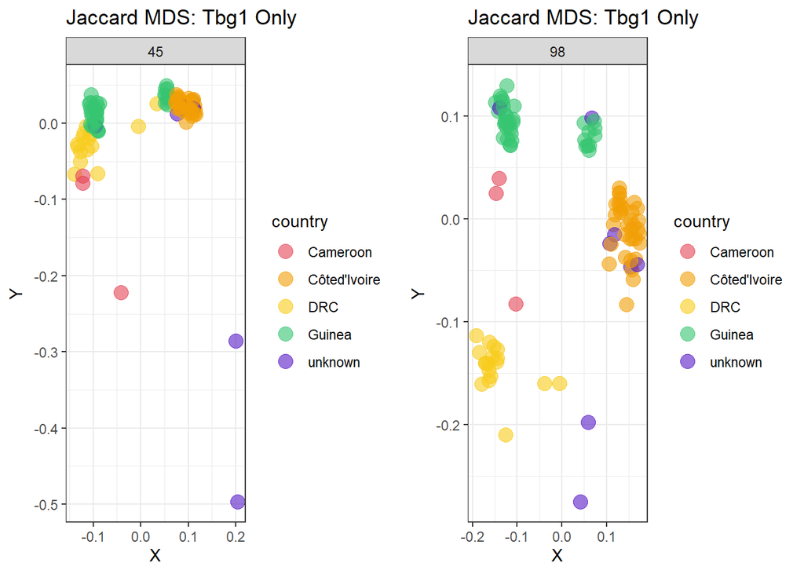

```r
# show 2 facets: a low one and the highest showing how populations diversify based on geography or year

plot_grid(tbg.jaccard.mds %>% filter(PID == 45) %>%
ggplot(aes(x=X, y=Y, text=sample,
           #label=sample,
           color=country))+
  #geom_text(nudge_x=0.01, nudge_y=0.01)+
  geom_point(size=4, alpha = 0.6)+
  facet_wrap(~PID)+
  ggtitle("Jaccard MDS: Tbg1 Only")+
  scale_color_manual(values = c("#e54456", "#f29f05", "#f8cc1b", "#36c570", "#571bc6"))+
  theme_bw(),
tbg.jaccard.mds %>% filter(PID == 98) %>%
ggplot(aes(x=X, y=Y, text=sample,
           #label=sample,
           color=country))+
  #geom_text(nudge_x=0.01, nudge_y=0.01)+
  geom_point(size=4, alpha = 0.6)+
  facet_wrap(~PID)+
  ggtitle("Jaccard MDS: Tbg1 Only")+
  scale_color_manual(values = c("#e54456", "#f29f05", "#f8cc1b", "#36c570", "#571bc6"))+
  theme_bw()
)
```

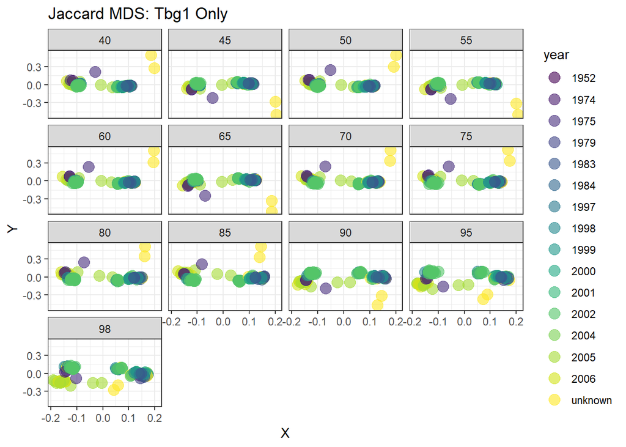

```r
g2 <- ggplot(data=tbg.jaccard.mds,
       aes(x=X, y=Y, text=sample,
           #label=sample,
           color=year))+
  #geom_text(nudge_x=0.01, nudge_y=0.01)+
  geom_point(size=4, alpha = 0.6)+
  facet_wrap(~PID)+
  ggtitle("Jaccard MDS: Tbg1 Only")+
  scale_color_viridis(discrete = T)+
  theme_bw()
g2
```

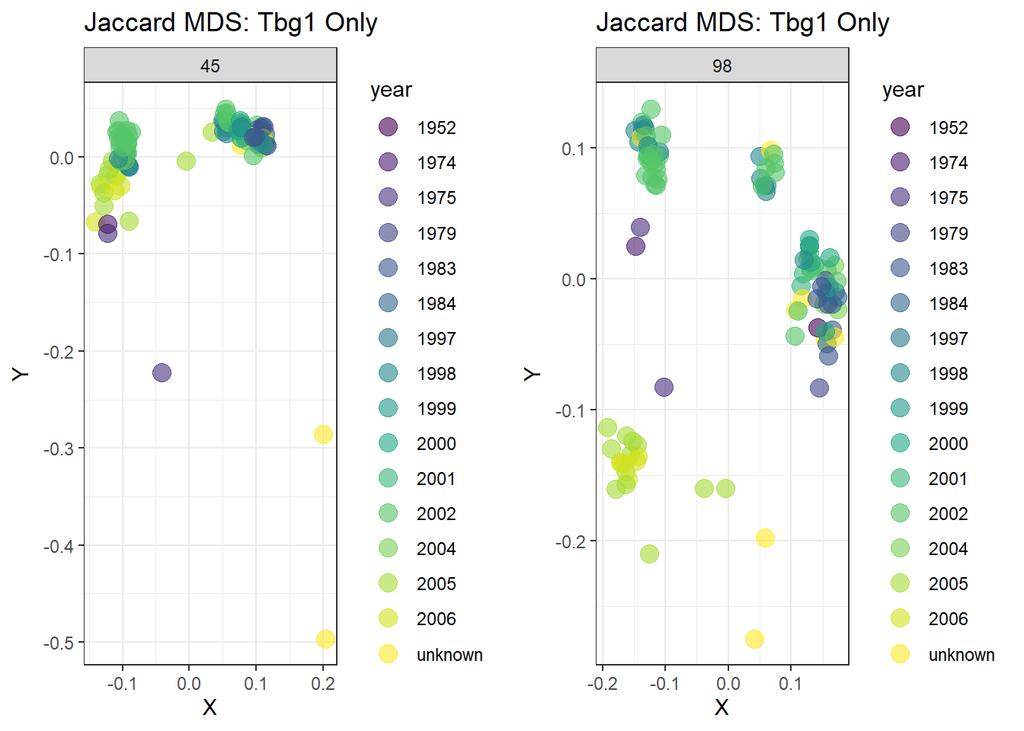

```r
plot_grid(tbg.jaccard.mds %>% filter(PID == 45) %>%
ggplot(aes(x=X, y=Y, text=sample,
           #label=sample,
           color=year))+
  #geom_text(nudge_x=0.01, nudge_y=0.01)+
  geom_point(size=4, alpha = 0.6)+
  facet_wrap(~PID)+
  ggtitle("Jaccard MDS: Tbg1 Only")+
  scale_color_viridis(discrete = T)+
  theme_bw(),
tbg.jaccard.mds %>% filter(PID == 98) %>%
ggplot(aes(x=X, y=Y, text=sample,
           #label=sample,
           color=year))+
  #geom_text(nudge_x=0.01, nudge_y=0.01)+
  geom_point(size=4, alpha = 0.6)+
  facet_wrap(~PID)+
  ggtitle("Jaccard MDS: Tbg1 Only")+
  scale_color_viridis(discrete = T)+
  theme_bw()
)
```

***

# Supplemental Figure S6B and S7B

Check that candidate diagnostic peptides are represented in relevant assembled genomes

```r
Tbr_diagnostics <- c("AF107887.1|270-360", "CAA85518.2|180-270", "Tb427VSG-1214|315-405", "Tb427VSG-1343|225-315", "Tb427VSG-1596|225-315", "Tb427VSG-2069|291-381", "Tb427VSG-340|439-529", "Tbb1125VSG-2036|405-495", "Tbb1125VSG-4218|406-496", "Tbb1125VSG-4304|90-180", "Tbb927VSG-1041|90-180", "Tbb927VSG-1611|45-135", "Tbb927VSG-1617|225-315", "Tbb1125VSG-5083|296-386", "Tbb1125VSG-1302|360-450", "Tbb1125VSG-1415|225-315")

Tbg_diagnostics <- c("Tb427VSG-2211|0-90", "Tbb1125VSG-6504|0-90", "Tbb1125VSG-2583|180-270", "Tb427VSG-1426|270-360", "Tbb1125VSG-246|45-135", "Tbb927VSG-147|45-135", "Tb427VSG-6146|0-90", "Tb427VSG-6609|90-180", "Tb427VSG-1015|90-180", "Tbb1125VSG-6008|45-135", "Tb427VSG-1008|45-135", "Tb427VSG-807|225-315", "KC434512.1|45-135", "Tb427VSG-3693|0-90", "Tbb1125VSG-1677|45-135", "Tbb927VSG-508|270-360", "Tbb1125VSG-292|270-360", "Tbb1125VSG-4200|45-135", "Tbb1125VSG-5577|45-135", "Tbb927VSG-507|45-135", "Tbb1125VSG-489|45-135", "Tb427VSG-2147|45-135", "Tbb1125VSG-4238|225-315", "Tbb1125VSG-6008|0-90", "KC434929.1|45-135", "Tb427VSG-626|45-135", "Tbb1125VSG-3176|0-90", "Tb427VSG-1604|260-350", "Tbb1125VSG-153|270-360", "Tbb1125VSG-1071|225-315")

candidate_align <- read_csv("FigureData/candidateList_matched.csv")
candidate_align <- candidate_align %>% mutate(length = qend - qstart)

diagnostic_rep <- inner_join(candidate_align %>% select(qseqid, sseqid, length) %>% group_by(qseqid, sseqid) %>% summarise(total = sum(length)),
                             Assembled_VSG, by = c("sseqid"="VSG_name"), relationship = "many-to-many")
# find the largest alignment to each tile for every strain
diagnostic_rep <- diagnostic_rep %>% group_by(qseqid, strain_name) %>% mutate(best = max(total)) %>% select(qseqid, strain_name, species, best) %>% distinct() %>% mutate(pct_cov = best/90 *100)

# add in the representation of SRA and ISG65
# assess whether these genes were identified in the assembled orf references
findSRA_ISG <- rbind(read_csv("FigureData/findSRA-ISG65/ERR270817_simple_trimmed_orf_findSRA_BlastScore.csv", show_col_types = FALSE) %>% mutate(strain_name = "GYBO"),
                     read_csv("FigureData/findSRA-ISG65/ERR270820_simple_trimmed_orf_findSRA_BlastScore.csv", show_col_types = FALSE) %>% mutate(strain_name = "K975_1"),
                     read_csv("FigureData/findSRA-ISG65/ERR270821_simple_trimmed_orf_findSRA_BlastScore.csv", show_col_types = FALSE) %>% mutate(strain_name = "Z210"),
                     read_csv("FigureData/findSRA-ISG65/ERR270825_simple_trimmed_orf_findSRA_BlastScore.csv", show_col_types = FALSE) %>% mutate(strain_name = "N1052"),
                     read_csv("FigureData/findSRA-ISG65/ERR273559_simple_trimmed_orf_findSRA_BlastScore.csv", show_col_types = FALSE) %>% mutate(strain_name = "K975_2"),
                     read_csv("FigureData/findSRA-ISG65/Tbr_LW024_orf_findSRA_BlastScore.csv", show_col_types = FALSE) %>% mutate(strain_name = "Tbr_LW024"),
                     read_csv("FigureData/findSRA-ISG65/Tbr_LW031_orf_findSRA_BlastScore.csv", show_col_types = FALSE) %>% mutate(strain_name = "Tbr_LW031"),
                     read_csv("FigureData/findSRA-ISG65/Tbr_LW032_orf_findSRA_BlastScore.csv", show_col_types = FALSE)  %>% mutate(strain_name = "Tbr_LW032"),
                     read_csv("FigureData/findSRA-ISG65/Tbr_LW041_orf_findSRA_BlastScore.csv", show_col_types = FALSE) %>% mutate(strain_name = "Tbr_LW041"))

findSRA_ISG %>% group_by(hit_name, strain_name) %>% summarise(best = max(percent_identity))
```

```
## # A tibble: 13 × 3
## # Groups:   hit_name [2]
##    hit_name                                                    strain_name  best
##    <chr>                                                       <chr>       <dbl>
##  1 gnl|BL_ORD_ID|0 AF107887.1 Trypanosoma brucei variant surf… GYBO         44.0
##  2 gnl|BL_ORD_ID|0 AF107887.1 Trypanosoma brucei variant surf… K975_1       38.6
##  3 gnl|BL_ORD_ID|0 AF107887.1 Trypanosoma brucei variant surf… K975_2       44.4
##  4 gnl|BL_ORD_ID|0 AF107887.1 Trypanosoma brucei variant surf… N1052        46.5
##  5 gnl|BL_ORD_ID|0 AF107887.1 Trypanosoma brucei variant surf… Tbr_LW024    46.5
##  6 gnl|BL_ORD_ID|0 AF107887.1 Trypanosoma brucei variant surf… Tbr_LW031    46.5
##  7 gnl|BL_ORD_ID|0 AF107887.1 Trypanosoma brucei variant surf… Tbr_LW041    46.7
##  8 gnl|BL_ORD_ID|0 AF107887.1 Trypanosoma brucei variant surf… Z210         44.2
##  9 gnl|BL_ORD_ID|1 Z37159.2 Trypanosoma brucei mRNA for VSG-l… K975_1       27.5
## 10 gnl|BL_ORD_ID|1 Z37159.2 Trypanosoma brucei mRNA for VSG-l… N1052        71.4
## 11 gnl|BL_ORD_ID|1 Z37159.2 Trypanosoma brucei mRNA for VSG-l… Tbr_LW031    23.5
## 12 gnl|BL_ORD_ID|1 Z37159.2 Trypanosoma brucei mRNA for VSG-l… Tbr_LW032    23.0
## 13 gnl|BL_ORD_ID|1 Z37159.2 Trypanosoma brucei mRNA for VSG-l… Z210         73.6
```

```r
Add_SRA_ISG <- findSRA_ISG %>% group_by(hit_name, strain_name) %>% summarise(best = max(percent_identity)) %>% mutate(qseqid = case_when(grepl("AF107887.1", hit_name)~"AF107887.1|270-360", grepl("Z37159.2", hit_name)~"CAA85518.2|180-270"), pct_cov = 100, species = "tbr") %>% select(qseqid, strain_name, species, best, pct_cov)
diagnostic_rep %>% filter(species == "tbr", qseqid == "CAA85518.2|180-270")
```

```
## # A tibble: 5 × 5
## # Groups:   qseqid, strain_name [5]
##   qseqid             strain_name species  best pct_cov
##   <chr>              <chr>       <chr>   <dbl>   <dbl>
## 1 CAA85518.2|180-270 Z210        tbr        15    16.7
## 2 CAA85518.2|180-270 Tbr_LW041   tbr        24    26.7
## 3 CAA85518.2|180-270 Tbr_LW024   tbr        24    26.7
## 4 CAA85518.2|180-270 Tbr_LW032   tbr        24    26.7
## 5 CAA85518.2|180-270 Tbr_LW031   tbr        24    26.7
```

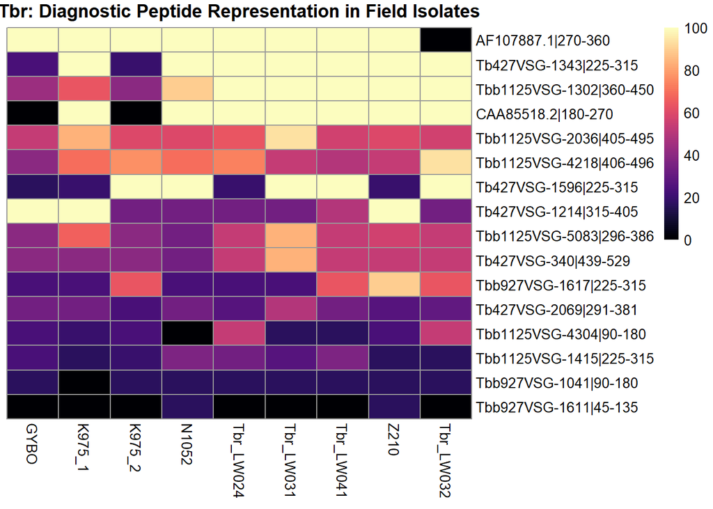

```r
# We are going to assume that if there is a blast hit then the gene is present
# ISG65 and SRA are functional proteins that shouldn't be diversifying the same way VSG do

Add_SRA_ISG <- rbind(Add_SRA_ISG, data.frame(qseqid = rep("CAA85518.2|180-270", 2),
                                             strain_name = c("Tbr_LW041", "Tbr_LW024"),
                                             species = rep("tbr", 2),
                                             best = rep(24, 2),
                                             pct_cov = rep(100, 2)))

hm_tbr <- diagnostic_rep %>% filter(species == "tbr", qseqid %in% Tbr_diagnostics, !(qseqid == "CAA85518.2|180-270")) %>% rbind(Add_SRA_ISG) %>% group_by(qseqid) %>% mutate(temp = sum(pct_cov)) %>% arrange(-temp) %>% ungroup() %>% dplyr::select(qseqid, strain_name, pct_cov) %>% pivot_wider(names_from = "strain_name", values_from = "pct_cov") %>% column_to_rownames(var = "qseqid") %>% as.matrix(.)
hm_tbr[is.na(hm_tbr)] <- 0


pheatmap(hm_tbr,
         show_colnames= T,
         show_rownames = T,
         cluster_cols = F,
         cluster_rows = F,
         #treeheight_row = 0,
         #breaks = c(0, 20, 40, 60, 80, 100),
         col = magma(100),
         main = "Tbr: Diagnostic Peptide Representation in Field Isolates"
         )
```

```r
hm_tbg <-
diagnostic_rep %>% filter(species == "tbg1", qseqid %in% Tbg_diagnostics) %>% group_by(qseqid) %>% mutate(temp = sum(pct_cov)) %>% arrange(-temp) %>% ungroup() %>% dplyr::select(qseqid, strain_name, pct_cov) %>% pivot_wider(names_from = "strain_name", values_from = "pct_cov") %>% column_to_rownames(var = "qseqid") %>% as.matrix(.)
# add the missing tile with no hits to the matrix
setdiff(Tbg_diagnostics, rownames(hm_tbg))
```

```
## [1] "Tb427VSG-6609|90-180"
```

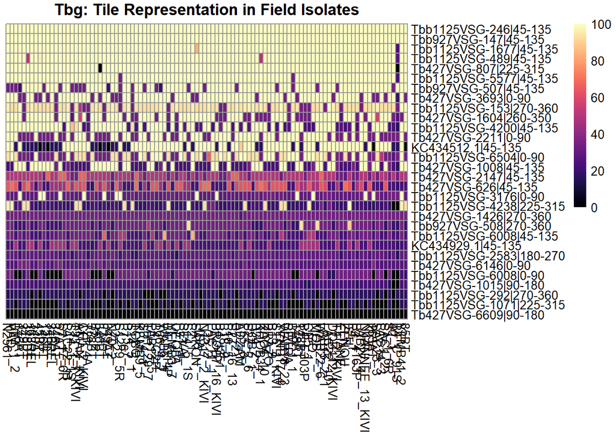

```r
Add_Missing <- matrix(nrow = 1, ncol = 100)
rownames(Add_Missing) <- setdiff(Tbg_diagnostics, rownames(hm_tbg))
colnames(Add_Missing) <- colnames(hm_tbg)
hm_tbg <- rbind(hm_tbg, Add_Missing)
hm_tbg[is.na(hm_tbg)] <- 0


pheatmap(hm_tbg,
         show_colnames= T,
         show_rownames = T,
         cluster_cols = F,
         cluster_rows = F,
         #treeheight_row = 0,
         #breaks = c(0, 20, 40, 60, 80, 100),
         col = magma(100),
         main = "Tbg: Tile Representation in Field Isolates"
         )
```

***

By [Jaime So](https://github.com/JSoSci/) for the [Mugnier Lab](https://www.mugnierlab.org/)

*jso4@jhmi.edu*